# MLB Batting Tendencies

By: Curtis Higa

## Pitcher's Dilemma

- Starting pitchers pitch once every 5 days
  - Typically last 6 innings
- Relief pitchers can pitch in multiple games in a row
  - Typically don't pitch more than 2 innings
- Pitchers get paid the same as everyday players

## Pitcher's Dilemma (cont.d)

- Studies to prevent pitcher injuries
  - Pitch count limitations
  - Pitchers most effecttive 20-70 pitches into game
- Doesn't solve how to maximize pitcher efficiency

## Pitcher Efficiency

- Want to maximize wins without spending too much $$Dollars\:per\:win = \frac{\sum(Player\:Salaries)}{Total\:Wins}$$ $$\approx \frac{\sum(Player\:Salaries)}{Runs\:Scored - Runs\:Allowed}$$

$$Runs\:Allowed \approx ERA \approx \frac{Runs}{Innings\:Pitched}$$ $$= \frac{3 \times Runs}{Number\:of\:Outs}$$

- More outs per pitches thrown

## Data

- Play-by-play data directly from MLB Gameday
  - Regular season games from 2015-2017

## Batting Tendencies

- Many idioms about how to pitch
  - "Hard stuff in, soft stuff away"
  - Breaking pitches up

## "Hard stuff in..."

### Right-Handed Batter

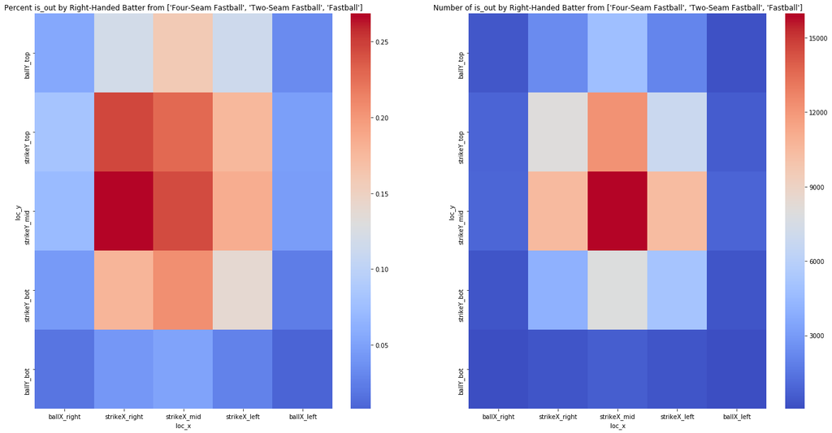

```python
# Plot a heatmap for hard stuff to right-handed batters
hs_right_outs_mean, hs_right_outs_count = heat_map(eda_df,
                                                   bat_side = 'Right',
                                                   pitch_types = hard_stuff,
                                                   call='is_out')
```

## "Hard stuff in..." (cont.d)

### Left-Handed Batter

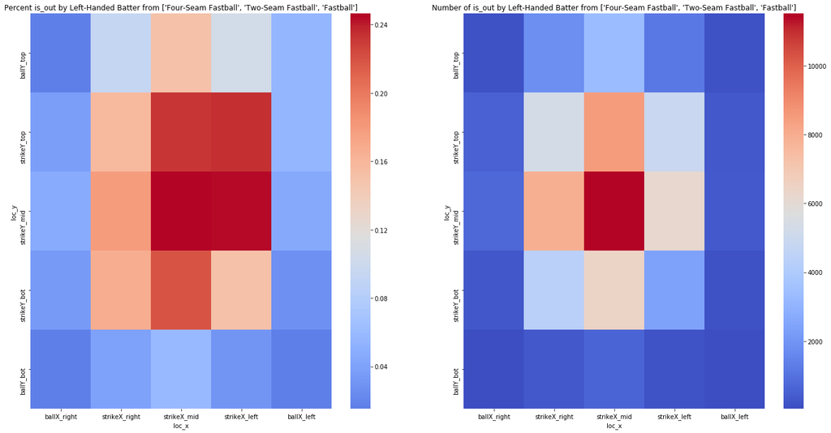

```python
# Plot a heatmap for hard stuff to left-handed batters
hs_left_outs_mean, hs_left_outs_count = heat_map(eda_df,
                                                 bat_side = 'Left',
                                                 pitch_types = hard_stuff,
                                                 call = 'is_out')
```

## "Hard stuff in..." (cont.d)

```python
# Test the significance of hard stuff in to right-handed batters
t_testing(eda_df,
          bat_side = 'Right',
          pitch_types = hard_stuff,
          call = 'is_out',
          locx_zone = ['strikeX_right'],
          locy_zone = ['strikeY_mid', 'stikeY_top', 'strikeY_bot'])
```

```
Total pitches: 57316. Mean is_out: 0.209209.
Total ['Four-Seam Fastball', 'Two-Seam Fastball', 'Fastball']: 61592. Mean is_out: 0.235485.
There's a statistical significance for getting is_out against Right-handed batters by throwing a ['Four-Seam Fastball', 'Two-Seam Fastball', 'Fastball'] at ['strikeX_right'] and ['strikeY_mid', 'stikeY_top', 'strikeY_bot'] opposed to other pitches
Test statistic: -10.901779. P-value: 0.000000
```

```python
# Test the significance of hard stuff in to left-handed batters
t_testing(eda_df,
          bat_side='Left',
          pitch_types=['Four-Seam Fastball', 'Two-Seam Fastball', 'Fastball'],
          call = 'is_out',
          locx_zone=['strikeX_left'],
          locy_zone=['strikeY_mid', 'stikeY_top', 'strikeY_bot'])
```

```
Total pitches: 43117. Mean is_out: 0.196883.
Total ['Four-Seam Fastball', 'Two-Seam Fastball', 'Fastball']: 41219. Mean is_out: 0.208569.
There's a statistical significance for getting is_out against Left-handed batters by throwing a ['Four-Seam Fastball', 'Two-Seam Fastball', 'Fastball'] at ['strikeX_left'] and ['strikeY_mid', 'stikeY_top', 'strikeY_bot'] opposed to other pitches
Test statistic: -4.218988. P-value: 0.000025
```

## "Hard stuff in..." (cont.d)

- Statistical difference in means
- May not have practical significance
  - Hard stuff is most commonly pitched

## "... Soft stuff away"

### Right-handed batters

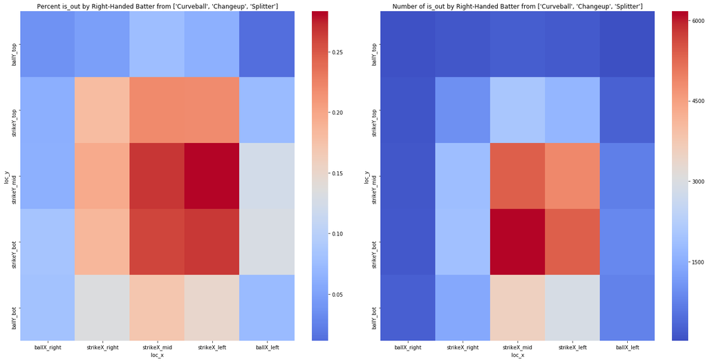

```python
ss_right_outs_mean, ss_right_outs_count = heat_map(eda_df,
                                                   'Right',
                                                   soft_stuff,
                                                   'is_out')
```

## "...Soft stuff away" (cont.d)

### Left-handed batters

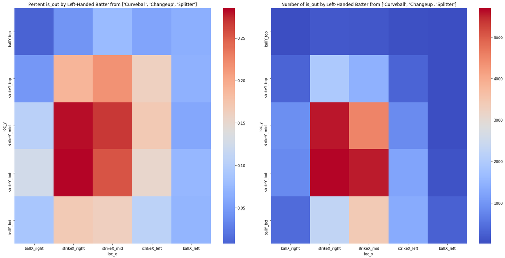

```python
ss_left_outs_mean, ss_left_outs_count = heat_map(eda_df,
                                                 bat_side = 'Left',
                                                 pitch_types = soft_stuff,
                                                 call = 'is_out')
```

## "...Soft stuff away" (cont.d)

```python
t_testing(eda_df,
         bat_side = 'Right',
         pitch_types = soft_stuff,
         locx_zone = ['strikeX_left'],
         locy_zone = ['strikeY_mid', 'strikeY_bot'],
         call = 'is_out')
```

```
Total pitches: 175662. Mean is_out: 0.197766.
Total ['Curveball', 'Changeup', 'Splitter']: 37387. Mean is_out: 0.273972.
There's a statistical significance for getting is_out against Right-handed batters by throwing a ['Curveball', 'Changeup', 'Splitter'] at ['strikeX_left'] and ['strikeY_mid', 'strikeY_bot'] opposed to other pitches
Test statistic: -30.546849. P-value: 0.000000
```

```python
t_testing(eda_df,
         bat_side = 'Left',
         pitch_types = soft_stuff,
         locx_zone = ['strikeX_right'],
         locy_zone = ['strikeY_mid', 'strikeY_bot'],
         call = 'is_out')
```

```
Total pitches: 111058. Mean is_out: 0.193782.
Total ['Curveball', 'Changeup', 'Splitter']: 39774. Mean is_out: 0.283778.
There's a statistical significance for getting is_out against Left-handed batters by throwing a ['Curveball', 'Changeup', 'Splitter'] at ['strikeX_right'] and ['strikeY_mid', 'strikeY_bot'] opposed to other pitches
Test statistic: -35.253647. P-value: 0.000000
```

## "...Soft stuff away" (cont.d)

- Statistical difference in means
- Practical significance
  - 8% for right-handers, 9% for left-handers

## Mistakes Up

### Right-handed batters

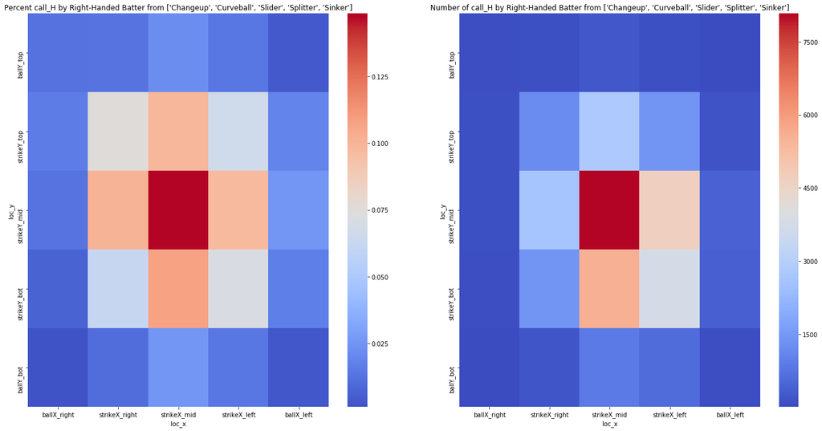

```python
mistakes_right_hit_mean, mistakes_right_hit_count = heat_map(eda_df,
                                                             bat_side = 'Right',
                                                             pitch_types = mistake_pitches,
                                                             call = 'call_H')
```

## Mistakes Up (cont.d)

### Left-handed batters

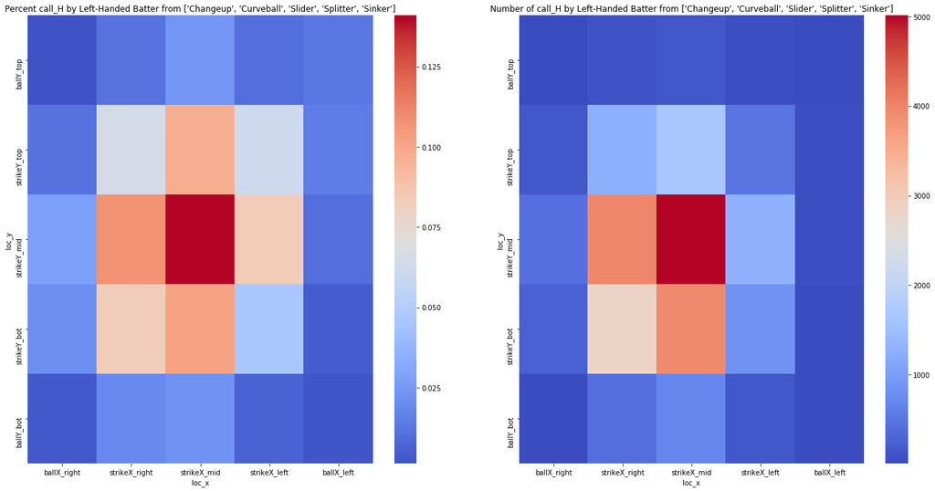

```python
mistakes_left_hit_mean, mistakes_left_hit_count = heat_map(eda_df,
                                                           bat_side = 'Left',
                                                           pitch_types = mistake_pitches,
                                                           call = 'call_H')
```

## Mistakes Up (cont.d)

```python
t_testing(eda_df,
         bat_side = 'Right',
         pitch_types = mistake_pitches,
         call = 'call_H',
         locx_zone = strikeX_zone,
         locy_zone = loc_up)
```

```
Total pitches: 326217. Mean call_H: 0.099881.
Total ['Changeup', 'Curveball', 'Slider', 'Splitter', 'Sinker']: 194131. Mean call_H: 0.107015.
There's a statistical significance for getting call_H against Right-handed batters by throwing a ['Changeup', 'Curveball', 'Slider', 'Splitter', 'Sinker'] at ['strikeX_right', 'strikeX_mid', 'strikeX_left'] and ['strikeY_top', 'strikeY_mid'] opposed to other pitches
Test statistic: -8.141250. P-value: 0.000000
```

```python
t_testing(eda_df,
         bat_side = 'Left',
         pitch_types = mistake_pitches,
         call = 'call_H',
         locx_zone = strikeX_zone,
         locy_zone = loc_up)
```

```
Total pitches: 237468. Mean call_H: 0.096194.
Total ['Changeup', 'Curveball', 'Slider', 'Splitter', 'Sinker']: 132641. Mean call_H: 0.103309.
There's a statistical significance for getting call_H against Left-handed batters by throwing a ['Changeup', 'Curveball', 'Slider', 'Splitter', 'Sinker'] at ['strikeX_right', 'strikeX_mid', 'strikeX_left'] and ['strikeY_top', 'strikeY_mid'] opposed to other pitches
Test statistic: -6.895932. P-value: 0.000000
```

## Mistakes Up (cont.d)

- Statistical difference in means
- Practical significance questionable
  - Possible difference in game impact
    - Bases allotted
    - Groundball vs. flyball

## Machine Learning

- Unsure if model would handle player ID numbers
- Uncertain if model would predict multi-label, multi-class reliably
- Created baseline models for comparison

## Machine Learning (cont.d)

- Outs, no player IDs
  - loss = 0.3835, accuracy = 0.8264, AUC = 0.5188
- Calls, no player IDs
  - loss = 0.3410, accuracy = 0.5105, AUC = 0.7880
- Outs, player IDs
  - loss = 0.3881, accuracy = 0.8262, AUC = 0.5304
- Calls, player IDs (*)
  - loss = 0.3443, accuracy = 0.5012, AUC = 0.7825

## model_calls_id

- 25 more models were created for fine tuning
  - All performed similiarly
- "Best" model
  - Validation loss = 0.3437
  - AUC = 0.6876
  - Hamming loss = 0.2229

## model_calls_id (cont.d)

- Per class metrics (F1 score)
  - Balls = 0.7532
  - Calls strikes = 0.5408
  - Fouls = 0.3971
  - Hits = 0.2137
  - Swinging strikes = 0.1781
  - Outs = 0.5473
- Trouble distinguishing hits and swinging strikes

## Future work

- Better handling of player ID numbers
- Incorporate who umpires
- Upsample least common class and/or downsample most common class
- Turn into multi-class classification